# Packet 2: Relationships among scales

Last updated 2018-04-07

This is an exploration of the relationships among scales included in Packet 2.

# Correlation matrix

First, let’s look at the overall correlationships among scores on the various scales included in Packet 2. (These are individual participant-level correlations):

```
Setting row names on a tibble is deprecated.
```

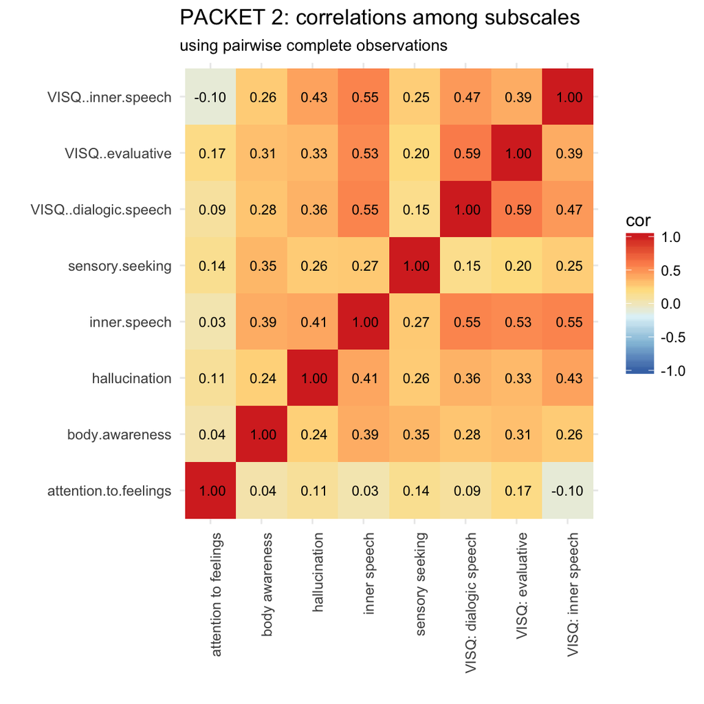

From this, we see that several of the scales included in Packet 2 were positively correlated with each other. Unsurprisingly, many of the “inner speech” subscales were positively correlated (all of the VISQ subscales and the Hardy/Bentall inner speech scale). But we also see some intriguing correlations among the inner speech scales and the “hallucination” scale (among other things). Let’s check these relationships out in more detail!

# Inner speech and “hallucinations”

## …as measured by Hardy/Bentall

Here’s a test for the overall correlation between inner speech as measured by the Hardy/Bentall scale, and hallucination-like experiences as measured by the Alderson-Day scale:

```
    Pearson's product-moment correlation

data:  inner speech and hallucination
t = 10.22, df = 519, p-value < 2.2e-16
alternative hypothesis: true correlation is not equal to 0
95 percent confidence interval:
 0.3352063 0.4784051
sample estimates:
      cor
0.4093233
```

Inner speech (as measured by Hardy/Bentall) was significantly positively correlated with reported hallucination-like events ($r$ = 0.41, $p$ = <0.001), accounting for approximately 17% of the variance in reported hallucinations.

Now let’s take a look at what’s going on in each site with a regression analysis:

|  | b | se | t | p |
| --- | --- | --- | --- | --- |
| baserate (overall) | 7.87 | 0.19 | 41.36 | <0.001 |
| baserate (ghana vs. overall) | -1.34 | 0.38 | -3.47 | <0.001 |
| baserate (thailand vs. overall) | -0.83 | 0.36 | -2.30 | 0.022 |
| baserate (china vs. overall) | -0.10 | 0.37 | -0.28 | 0.781 |
| baserate (vanuatu vs. overall) | 0.24 | 0.42 | 0.58 | 0.564 |
| HB inner speech (overall) | 0.33 | 0.03 | 10.98 | <0.001 |
| HB inner speech (ghana vs. overall) | 0.07 | 0.07 | 1.10 | 0.270 |
| HB inner speech (thailand vs. overall) | -0.14 | 0.05 | -2.71 | 0.007 |
| HB inner speech (china vs. overall) | -0.03 | 0.06 | -0.48 | 0.631 |
| HB inner speech (vanuatu vs. overall) | -0.18 | 0.06 | -2.90 | 0.004 |

These results indicate that there was a significant positive relationship between inner speech (as measured by Hardy/Bentall) and reported hallucination-like events, collapsing across sites ($b$ = 0.33, $p$ = <0.001). The relationship between inner voice and hallucinations was somewhat weaker among participants in Thailand and Vanuatu (Thailand: $b$ = -0.14, $p$ = 0.007; Vanuatu: $b$ = -0.18, $p$ = 0.004).

Note also that this test picked up on some differences in the baserates for reporting hallucination-like events (controlling for the relationships described above): Participants in Ghana and Thailand seem to have reported fewer than average of these kinds of events (Ghana: $b$ = -1.34, $p$ = <0.001; Thailand: $b$ = -0.83, $p$ = 0.022).

Here’s a visualization of these relationships:

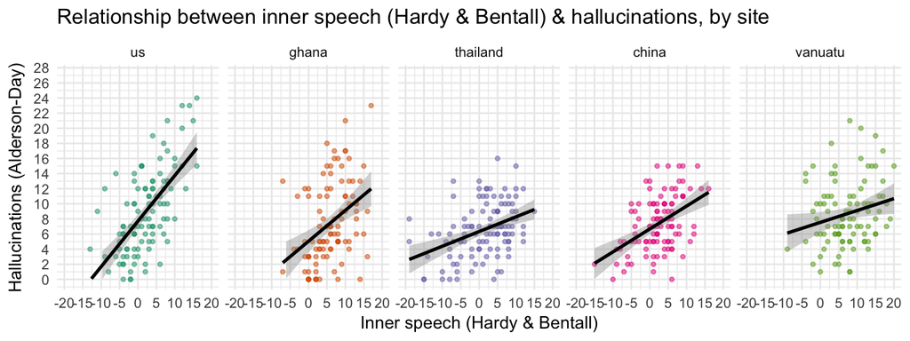

## …as measured by the “inner speech” subscale of the VISQ

Here’s a test for the overall correlation between inner speech as measured by the VISQ “inner speech” subscale, and hallucination-like experiences as measured by the Alderson-Day scale:

```
    Pearson's product-moment correlation

data:  VISQ: inner speech and hallucination
t = 10.801, df = 519, p-value < 2.2e-16
alternative hypothesis: true correlation is not equal to 0
95 percent confidence interval:
 0.3555767 0.4960437
sample estimates:
      cor
0.4283949
```

Inner speech (as measured by VISQ) was significantly positively correlated with reported hallucination-like events ($r$ = 0.43, $p$ = <0.001), accounting for approximately 18% of the variance in reported hallucinations.

Now let’s take a look at what’s going on in each site with a regression analysis:

|  | b | se | t | p |
| --- | --- | --- | --- | --- |
| baserate (overall) | 7.76 | 0.19 | 40.18 | <0.001 |
| baserate (ghana vs. overall) | -0.46 | 0.37 | -1.25 | 0.210 |
| baserate (thailand vs. overall) | -0.62 | 0.38 | -1.65 | 0.100 |
| baserate (china vs. overall) | -0.32 | 0.37 | -0.88 | 0.378 |
| baserate (vanuatu vs. overall) | -0.30 | 0.44 | -0.68 | 0.496 |
| VISQ inner speech (overall) | 0.48 | 0.05 | 10.56 | <0.001 |
| VISQ inner speech (ghana vs. overall) | 0.02 | 0.09 | 0.21 | 0.832 |
| VISQ inner speech (thailand vs. overall) | -0.15 | 0.09 | -1.65 | 0.099 |
| VISQ inner speech (china vs. overall) | -0.09 | 0.09 | -1.04 | 0.298 |
| VISQ inner speech (vanuatu vs. overall) | -0.02 | 0.10 | -0.18 | 0.858 |

As above, these results indicate that there was a significant positive relationship between inner speech (as measured by the VISQ) and reported hallucination-like events, collapsing across sites ($b$ = 0.48, $p$ = <0.001). This test did not pick up on any substantial differences in the strength of this relationship across sites.

In the context of this test (i.e., controlling for these relationships), the differences across sites in overall baserates for reporting hallcunination-like events were not significant.

Here’s a visualization of these relationships:

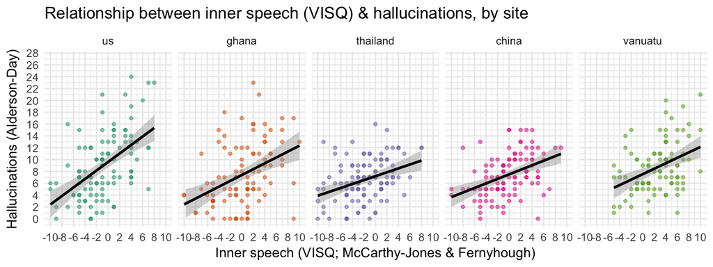

## …as measured by the “dialogic speech” subscale of the VISQ

Here’s a test for the overall correlation between dialogic speech as measured by the VISQ “dialogic speech” subscale, and hallucination-like experiences as measured by the Alderson-Day scale:

```
    Pearson's product-moment correlation

data:  VISQ: dialogic speech and hallucination
t = 8.8294, df = 517, p-value < 2.2e-16
alternative hypothesis: true correlation is not equal to 0
95 percent confidence interval:
 0.2847847 0.4345129
sample estimates:
      cor
0.3619812
```

Dialogic speech (as measured by VISQ) was significantly positively correlated with reported hallucination-like events ($r$ = 0.36, $p$ = <0.001), accounting for approximately 13% of the variance in reported hallucinations.

Now let’s take a look at what’s going on in each site with a regression analysis:

|  | b | se | t | p |
| --- | --- | --- | --- | --- |
| baserate (overall) | 7.87 | 0.19 | 41.11 | <0.001 |
| baserate (ghana vs. overall) | -0.24 | 0.38 | -0.65 | 0.515 |
| baserate (thailand vs. overall) | -1.24 | 0.36 | -3.43 | <0.001 |
| baserate (china vs. overall) | -0.46 | 0.37 | -1.22 | 0.222 |
| baserate (vanuatu vs. overall) | 0.28 | 0.43 | 0.66 | 0.508 |
| VISQ dialogic speech (overall) | 0.57 | 0.07 | 8.14 | <0.001 |
| VISQ dialogic speech (ghana vs. overall) | 0.09 | 0.15 | 0.61 | 0.544 |
| VISQ dialogic speech (thailand vs. overall) | -0.15 | 0.13 | -1.19 | 0.233 |
| VISQ dialogic speech (china vs. overall) | -0.08 | 0.14 | -0.58 | 0.565 |
| VISQ dialogic speech (vanuatu vs. overall) | -0.12 | 0.17 | -0.75 | 0.453 |

These results indicate that there was a significant positive relationship between dialogic speech (as measured by the VISQ) and reported hallucination-like events, collapsing across sites ($b$ = 0.57, $p$ = <0.001). This test did not pick up on any substantial differences in the strength of this relationship across sites.

Here’s a visualization of these relationships:

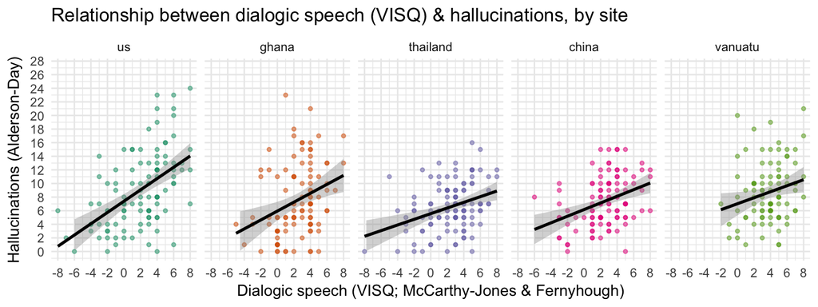

## …as measured by the “evaluative speech” subscale of the VISQ

Here’s a test for the overall correlation between evaluative as measured by the VISQ “evaluative/motivational speech” subscale, and hallucination-like experiences as measured by the Alderson-Day scale:

```
    Pearson's product-moment correlation

data:  VISQ: evaluative and hallucination
t = 8.0595, df = 519, p-value = 5.31e-15
alternative hypothesis: true correlation is not equal to 0
95 percent confidence interval:
 0.2549155 0.4077376
sample estimates:
      cor
0.3335157
```

Evaluative/motivational speech (as measured by VISQ) was significantly positively correlated with reported hallucination-like events ($r$ = 0.33, $p$ = <0.001), accounting for approximately 11% of the variance in reported hallucinations.

Now let’s take a look at what’s going on in each site with a regression analysis:

|  | b | se | t | p |
| --- | --- | --- | --- | --- |
| baserate (overall) | 7.88 | 0.19 | 40.48 | <0.001 |
| baserate (ghana vs. overall) | -0.40 | 0.38 | -1.07 | 0.284 |
| baserate (thailand vs. overall) | -0.97 | 0.37 | -2.59 | 0.010 |
| baserate (china vs. overall) | -1.20 | 0.41 | -2.93 | 0.004 |
| baserate (vanuatu vs. overall) | 0.55 | 0.40 | 1.35 | 0.177 |
| VISQ eval/motiv (overall) | 0.61 | 0.08 | 8.00 | <0.001 |
| VISQ eval/motiv (ghana vs. overall) | -0.10 | 0.14 | -0.69 | 0.491 |
| VISQ eval/motiv (thailand vs. overall) | -0.15 | 0.14 | -1.07 | 0.287 |
| VISQ eval/motiv (china vs. overall) | 0.05 | 0.18 | 0.28 | 0.780 |
| VISQ eval/motiv (vanuatu vs. overall) | -0.29 | 0.16 | -1.82 | 0.070 |

Here’s a visualization of these relationships:

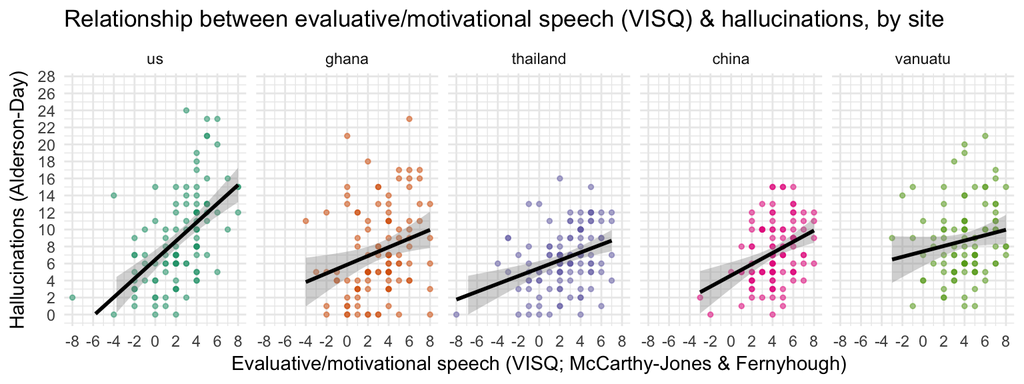